# Optimising Knots with Splines

# ——————————————————————————–

### Simulation of Data

First a pharmacokinetic model is simulated

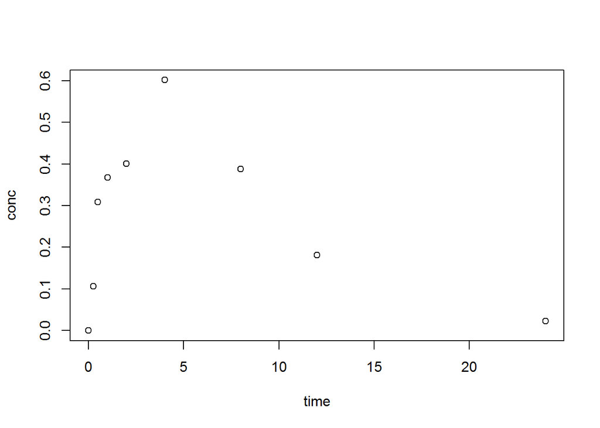

```r
# Remove all current objects in the workspace
  rm(list = ls(all = TRUE))
  set.seed(123)

#  So, consider the following dataset, with the following spline regression,
  library(splines)
  library(ggplot2)
# Set ggplot2 theme
  theme_bw2 <- theme_set(theme_bw(base_size = 14))

  K <- c(5, 10)  # knots
  CL <- 10  # Clearance, 10 L/h
  V <- 50   # Volume of concribution, 50 L
  KA <- 0.5 # Absorption rate constant, h^-1
  ERR <- 0.3    # Standard deviation of error
  dose <- 50    # mg
  times <- seq(from = 0,to = 24,by = 0.25)  # Time sequence for simulation
  sample.times <- c(0,0.25,0.5,1,2,4,8,12,24)   # Sampling times
  conc <- dose*KA/(V*(KA - (CL/V)))*(exp(-CL/V*times) - exp(-KA*times))*
    (1 + rnorm(n = length(times), mean = 0, sd = ERR))
  sample.conc <- conc[times %in% sample.times]
  onecomp <- data.frame(time = sample.times, conc = sample.conc)
  plot(onecomp)
```

### Best Placement of Knots

Using this simulation we can view where the best place for knots to be.

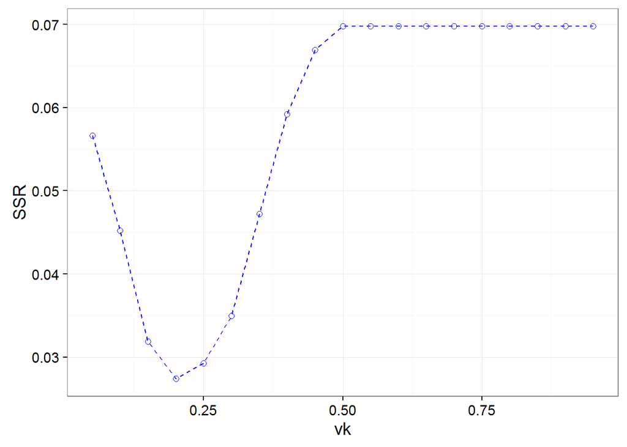

```r
  vk <- seq(0.05, 0.95, by = 0.05)
  SSR <- matrix(NA, length(vk))
  for(i in 1:(length(vk))){
    k <- vk[i]
    K <- min(onecomp$time) + k*(max(onecomp$time) - min(onecomp$time))
    reg <- lm(conc ~ bs(time, knots = c(K), degree = 2), data = onecomp)
    SSR[i] <- sum(residuals(reg)^2)
  }
  dat <- data.frame(vk, c(SSR))
  plotobj <- ggplot(dat, aes(x = vk, y = SSR))
  plotobj <- plotobj + geom_point(shape = 21, size = 2, colour = "blue")
  plotobj <- plotobj + geom_line(linetype = 2, colour = "blue")
  plotobj
```

By using an objective function value we can optimise the number of knots that a spline uses.

### Building splines

To start need a base set of spline functions to facilitate this.

```r
# Create a function to create a spline
  predict.spline.func <- function(x) {
    mod <- lm(
      x$Y ~ bs(x$X, knots = x$K, degree = x$n)
    )  # lm
    B <- data.frame(time = x$X)
    Y <- predict(mod, newdata = B)
  }
```

Here we have a function that takes a list as input, then uses the lm() function to fit a spline to the time intervals. This spline is then used to produce predicted concentrations.

```r
# Wrapper that calculates residuals to be minimised
  spline.oneknot.func <- function(par, Cobs, time, degree) {
    param <- list(
      X = time,
      Y = Cobs,
      K = par[1],
      n = degree
    )
    Chat <- predict.spline.func(param)
    err <- Cobs-Chat
    squ.err <- err^2
    sse <- sum(squ.err)  # Sum of squared errors to be minimised
    sse
  }
```

By incorporating this into a function that calculates the sum of square errors for the observed and predicted concentrations we get an objective function value.

Using optim() we can optimise the par argument that goes into the function above. In this case the par argument are the knots of the spline.

```r
# Initial estimates
  tmax <- onecomp$time[which(onecomp$conc == max(onecomp$conc))]
    init.par <- c(tmax)
  #par <- init.par

# Minimise the sum of squared errors
# Using the optim function in R
    result <- optim(
        init.par,  # Initial parameter estimates
        spline.oneknot.func,  # Fitting function
    # method = "SANN",
    method = "L-BFGS-B", lower = 0, upper = 24,
    # method = "Brent", lower = 0, upper = 24,
        Cobs = onecomp$conc, time = onecomp$time, degree = 2  # Function arguments
    )
    result  # Print the result
```

```
## $par
## [1] 4.74806
##
## $value
## [1] 0.02740456
##
## $counts
## function gradient
##        8        8
##
## $convergence
## [1] 0
##
## $message
## [1] "CONVERGENCE: REL_REDUCTION_OF_F <= FACTR*EPSMCH"
```

When using two knots, optim is determining two numbers. This is straight forward for optim(), but how do we stop optim() from choosing two knots that are too close to one another? Two ways to use the knots. * Determine two numbers independent of one another * Determine the first knot, and then the distance from the previous knot

```r
# Wrapper using unique unrelated parameters
  uq.spline.twoknot.func <- function(par, Cobs, time, degree) {
    param <- list(
      X = time,
      Y = Cobs,
      K = c(par[1], par[2]),
      n = degree
    )
    Chat <- predict.spline.func(param)
    err <- Cobs-Chat
    squ.err <- err^2
    sse <- sum(squ.err)  # Sum of squared errors to be minimised
    sse
  }

# Wrapper using the distance from last knot method
  lk.spline.twoknot.func <- function(par, Cobs, time, degree) {
    param <- list(
      X = time,
      Y = Cobs,
      K = c(par[1], par[1] + par[2]),
      n = degree
    )
    Chat <- predict.spline.func(param)
    err <- Cobs-Chat
    squ.err <- err^2
    sse <- sum(squ.err)  # Sum of squared errors to be minimised
    sse
  }
```

How different are these two methods?

```r
# Initial estimates
  tmax <- onecomp$time[which(onecomp$conc == max(onecomp$conc))]
    init.par <- c(tmax, tmax)
  #par <- init.par

# Minimise the sum of squared errors
# Using the optim function in R
    result1 <- optim(
        init.par,  # Initial parameter estimates
        lk.spline.twoknot.func,  # Fitting function
    # method = "SANN",
    method = "L-BFGS-B", lower = 0, upper = 24,
        Cobs = onecomp$conc, time = onecomp$time, degree = 2  # Function arguments
    )

  init.par <- c(tmax, tmax*2)

  result2 <- optim(
        init.par,  # Initial parameter estimates
        uq.spline.twoknot.func,  # Fitting function
    # method = "SANN",
    method = "L-BFGS-B", lower = 0, upper = 24,
        Cobs = onecomp$conc, time = onecomp$time, degree = 2  # Function arguments
    )

# Print result
    list(
      Dependent = result1,
      Independent = result2
    )
```

```
## $Dependent
## $Dependent$par
## [1] 4.213064 3.995307
##
## $Dependent$value
## [1] 0.02693773
##
## $Dependent$counts
## function gradient
##        6        6
##
## $Dependent$convergence
## [1] 0
##
## $Dependent$message
## [1] "CONVERGENCE: REL_REDUCTION_OF_F <= FACTR*EPSMCH"
##
##
## $Independent
## $Independent$par
## [1] 4.183794 7.982171
##
## $Independent$value
## [1] 0.02693773
##
## $Independent$counts
## function gradient
##        6        6
##
## $Independent$convergence
## [1] 0
##
## $Independent$message
## [1] "CONVERGENCE: REL_REDUCTION_OF_F <= FACTR*EPSMCH"
```

The two methods have identical objective function values. These two methods should probably be stress tested in the future to determine which is better.

Three knots were tried, however this seems to be too many. Might be ok for more complex models, 2 knots is already alot of knots for 7 internal concentration points.

```r
spline.threeknot.func <- function(par, Cobs, time, degree) {
  param <- list(
    X = time,
    Y = Cobs,
    K = c(par[1], par[1] + par[2], par[1] + par[2] + par[3]),
    n = degree
  )
  Chat <- predict.spline.func(param)
  err <- Cobs-Chat
  squ.err <- err^2
  sse <- sum(squ.err)  # Sum of squared errors to be minimised
  sse
}
```

We may need a rule for the max number of knots for the amount of concentrations that you fit a spline to.

### Building a Flexible Spline Function

Because we are carrying the last knot method forward we need a function that adds each value with the value before.

```r
# Takes a vector x[1], x[2], ..., x[length(x)]
# Calculates sum(x[1]),  sum(x[1], x[2]), ...
  knot.func <- function(x) {
    y <- double(length(x))
    for (i in 1:length(x)) {
      y[i] <- sum(x[1:i])
    }
    return(y)
  }
```

We can now use this to create a flexible spline optimising function that manages any amount of knots that we throw at it!

```r
# Combines the previous functions into one!
  error.spline.func <- function(par, Cobs, time, degree) {
    param <- list(
      X = time,
      Y = Cobs,
      K = knot.func(par),
      n = degree
    )
    Chat <- predict.spline.func(param)
    err <- Cobs-Chat
    squ.err <- err^2
    sse <- sum(squ.err)  # Sum of squared errors to be minimised
    sse
  }
```

So now this function can be used as a reliable and flexible function within optim(), but optim() doesn’t work with integers and you can’t have 1.5 knots.

This is addressed by trying each number of knots up to a maximum number of knots and determining which is best. A maximum is needed, because without one you would always end up with a very squiggly spline.

A rule could be designed instead of having the user specify the maximum knots, but this would need to be stress tested as you would expect that the maximum amount of knots will almost always provide a better fit.

Another issue here is there is currently no control for points being too close to one another. Knots that are close to each other cause the spline to deviate dramatically from a typical PK curve. There may need to be some sort of penalty when knots are too close to one another.

The current boundaries used are 0 and 24 (the min and max time interval present in the data). These boundaries are fine for the first knot, but not for the second knot with the last knot method. Theoretically the second knot may appear outside of our time interval, which is no good for splines.

### Final Knot Optimisation Function

The current function in use is featured below:

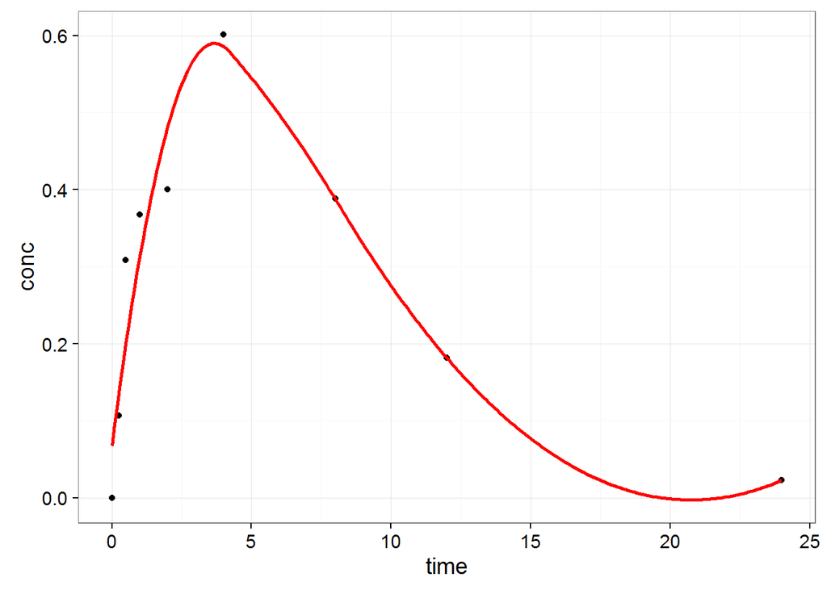

```r
  which.knots <- function(x, y, max.knots, degree) {
    xmax <- x[which(y == max(y))]
    err <- NULL
    knots <- list(NULL)
    for (i in 1:max.knots) {
      par <- rep(xmax, i)
      opt.res <- optim(
        par,  # Initial parameter estimates
        error.spline.func,  # Fitting function
        # method = "SANN",
        method = "L-BFGS-B", lower = min(x), upper = max(x),
        Cobs = y, time = x, degree = 2  # Function arguments
      )
      err[i] <- opt.res$value
      knots[[i]] <- knot.func(opt.res$par)
    }
    knots[[which(err == min(err))]]
  }
  K <- which.knots(onecomp$time, onecomp$conc, 2, 2)

  reg <- lm(conc ~ bs(time, knots = c(K), degree = 2), data = onecomp)
  u <- seq(0, 24, by = 0.1)  # test model at these times
  B <- data.frame(time = u)  # data.frame(times)
  Y <- predict(reg, newdata = B)  # predicted conc for the desired times
  plotobj <- ggplot()
  plotobj <- plotobj + geom_point(aes(x = time, y = conc), data = onecomp)
  plotobj <- plotobj + geom_line(aes(x = u, y = Y), size = 1, colour = "red")
  plotobj
```

Limitiations of current function: * Could be possible for knots after the first knot to minimise outside the time interval * If xmax is more than 1/max.knots of max(x) then par will exceed the bounds * Excessive warnings appear when multiple knots are between internal points this is due to a rank-deficient fit, I think this is because it’s probably not enough information to have two knots between two internal points

### Conclusion

The work presented here gives us predicted concentrations that can be used for optimising sampling intervals. It optimises the knots, however does not address the need to optimise for degrees (if there is in fact a need for this is uncertain).